# Notes

### Overview to AI

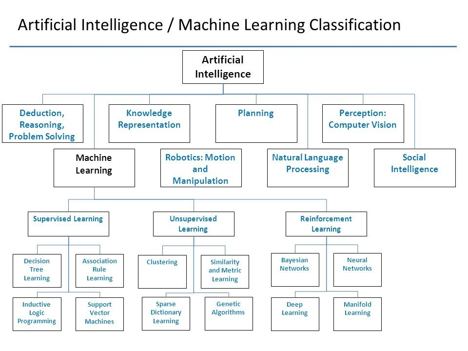

#### Download source for datasets:

1. Uci machinelearning repo
2. Kaggle

#### Reference books:

1. Business Analytics By Dinesh Kumar
2. Machine Learning using python By Manaranjan Pradhan
3. Python Machine Learning By Sebastian Raschka

#### Rules for prediction:

Factors are which that we thought can influence our prediction  
1) Factors should be quantifiable and measurable  
2) Historical evidence for factors (multiple evidence)  
3) Time lag between factors and outcomes should be in consistence with problem statement  
4) History should repeat itself. (If context is change or factors itself changing then historical data can’t be use)

Number of evidence = number of factors * 10

If outcome is numerical it called regression problem.  
If outcome is categorical it called classification problem.

Supervised Learning -> Regressoin and Classification  
Unsupervised Learning -> Clustering

Y = f(x1, x2, ... xn)  
x is Factors/features/Independent variables  
y is outcome,target or dependent variables

Variance = 1/N Sum(x1 - X{Mean})2  
correlation = SUM((x1 - X{Mean})*(Y1 - Y{MEAN})/std(x)*std(y))  
std = Standard Deviation

For all regression model try to reduce MSE. (Mean squared error)

#### K fold Cross validation:

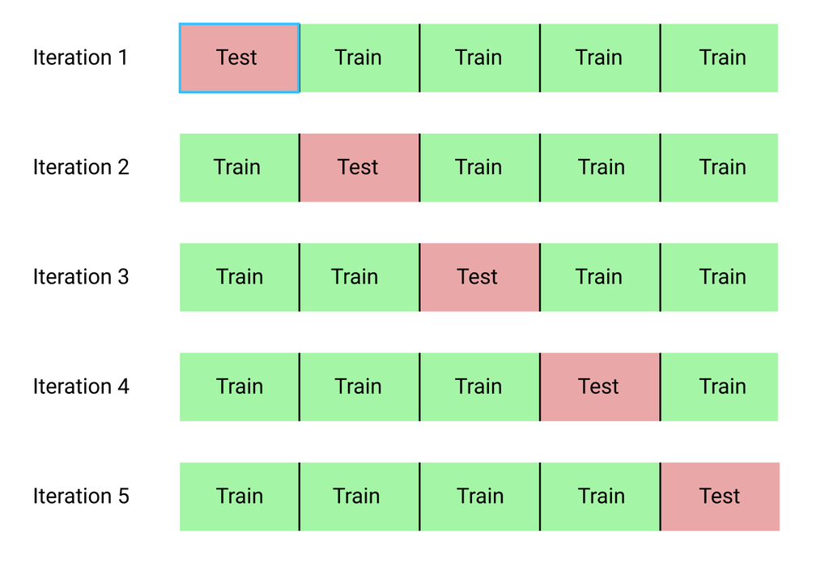

### Process of building Regression model

1. Identify outcome variable an feature variable
2. If any categorical features then create dummy variable
3. Split data in training and test data
4. Build a model using training date using cross validation
5. Check accuraccy using R squared
6. If R squared is not good do following a. Feature engineering b. use different model c. add more factors
7. Repeat 4 to 6 steps.
8. Select a model and test it against test dataset
9. Calculate RMSE

### Process of building Classification model

1. Identify outcome variable an feature variable
2. If any categorical features then create dummy variable
3. Split data in training and test data
4. Build a model check confusion matrix
5. Identify which qundrants are important to business and assign cost
6. Calculate cut off probability using cost
7. Test it against test data
8. Calculate presion, recall and f1 factor

#### For Decision Tree

1) Install Graphviz  
2) Stop all notebooks  
3) Stop jupyter notebook  
4) Add graphviz bin folder to path  
5) Restart your anaconda  
6) pip install pydotplus  
7) Start jupyter notebook

## Unsupervised Learning (Clustering)

1. For clustering we have to normalize data first. So that they can come to same scale. e.g. If some data is [100, 200] and other data is [0.1,0.2] than these data are not in same scale (we may use percentage change, ratio etc) Use Standard scaler.

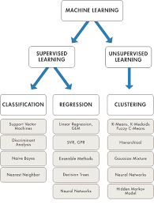